# Main Project

Celina

10/28/2021

# Downloading the Data and joining

```r
#Demographic Data
demo_2019 <- read_csv("data\\WICounty2019Demographics.csv", skip = 1) %>%
  select(-matches("(Margin)|(Percent)|(ratio)|(_1)"), -id) %>%
  select(matches("(Total population)|(Geographic Area)")) %>%
  select(-matches("Hispanic or Latino \\(of any race\\)!!"),
         -matches("American Indian and Alaska Native!!"),
         -matches("Asian!!"),
         -matches("Native Hawaiian and Other Pacific Islander!!"),
         -matches("Two or more races!"),
         -matches("and over$"),
         -matches("Race alone or in combination with one or more other races!!")) %>%
  rename_all(funs(str_replace_all(., "((Estimate!!)|(Total population!!)+)", ""))) %>%
  rename(County = "Geographic Area Name") %>%
  mutate(County = sub(" County, Wisconsin", "", County))

#Income Data
income_2019 <- read_csv("data\\WICounty2019Income.csv", na = "N", skip=1) %>%
  select(-id,-matches("(Margin)|(Distribution)")) %>%
  select(-matches("race"), -matches("FAMILIES!!families!!")) %>%
  rename_all(funs(str_replace_all(., "((Estimate!!)|(Number!!))+", ""))) %>%
  rename(County = "Geographic Area Name")%>%
  mutate(County = sub(" County, Wisconsin", "", County))

#Library Data
library_data <- readxl::read_excel("data\\public_library_service_data_2019.xlsx", sheet = "2019 PRELIMINARY DATA", skip = 1) %>%
  slice(-1) %>%
  select(-c(
            "Library ID",
            "Municipality",
            "Public Library System",
            "Branches",
            "15. No. of Bookmobiles Owned",
            "Other Service Outlets",
            "Books-by-Mail",
            "Joint Library under s.43.53 1=Yes",
            "Participating Municipalities",
            "Circulation Count Method: Actual / Survey",
            "Locale Code",
            "Other Material Description"),
         -matches("(Outlay)|(Access Denied)|(Databases)|(Circulation)|(Collection Retrievals)"))

data <- library_data %>%
  na_if("0") %>%
  left_join(demo_2019, by="County") %>%
  inner_join(income_2019, by="County")
```

#### General Introduction: Understanding the data and where funding goes

________________________ **READ ME** ______________________________________

I’ve created three new datasets: 1. `programs_staff` = Number of Programs and Staff per County 2. `Library_income_costs` = Total Income and Costs for library (All Numbers here are in Dollars)  
3. `computer_usage_data` = All Computer Usage by county (column names explain more)

Notes for all three datasets: 1. I’ve renamed all the columns to remove spaces so we don’t have to use ` anymore and RStudio can autocomplete the variables  
2. I’ve dropped all the rows that contain missind data for each new dataset. We can add that back in later if we want but, for now they are dropped. 3. All numbers in the new datasets are actual numbers and not character strings so you can use math functions on them.

```r
programs_staff <- data %>%
  select(County, matches("(Number .*Program)|(Librarians)|(Staff)"), "Total Income") %>%
  drop_na() %>%
  rename_all(funs(str_replace_all(., " ", "_"))) %>%
  mutate(across(.cols=-c(County), as.numeric)) %>%
  group_by(County) %>%
  mutate(across(.cols=everything(), sum)) %>%
  unique()


library_income_costs <- data %>%
  select(County, "Total Income",
         "Salaries & Wages",
         "Print Materials",
         "Electronic format",
         "Audiovisual Materials",
         "Contracted Services",
         "Other Operating Expenditures",
         "Total Operating Expenditures",
         "Resident Support per Capita (Local Revenues and Resident Population)") %>%
  rename(Library_Income = `Total Income`) %>%
  rename_all(funs(str_replace_all(., " ", "_"))) %>%
  rename(Resident_Support_per_Capita = `Resident_Support_per_Capita_(Local_Revenues_and_Resident_Population)`) %>%
  drop_na() %>%
  mutate(across(.cols=-c(County), as.numeric)) %>%
  group_by(County) %>%
  mutate(across(.cols=everything(), sum)) %>%
  unique()

# Note: Library focuses activies on Children (0-11), Young Adults (12-18), and other.
# They only recorded the Number of Uses of computers, they didn't divide it based on if they had access to Wifi
# Not all locations record Wireless Uses or Library Visits but, I thought they could be useful.

computer_Usage_Data <- data %>%
  select(County,
         matches("SEX AND AGE"),
         -matches("(Male)|(Female)|(Median)"),
         "Median income (dollars)!!FAMILIES!!Families",
         "Median income (dollars)!!NONFAMILY HOUSEHOLDS!!Nonfamily households",
          matches("Computers"), "Wireless Internet Uses",
         "Library Visits") %>%
  drop_na() %>%
  rename(Total_Population = "SEX AND AGE!!Total population",
         Income_Familes = "Median income (dollars)!!FAMILIES!!Families",
         Income_NonFamily = "Median income (dollars)!!NONFAMILY HOUSEHOLDS!!Nonfamily households") %>%
  rename_all(funs(str_replace_all(., "((SEX AND AGE!!)|( years))+", ""))) %>%
  rename_all(funs(str_replace_all(., " ", "_"))) %>%
  mutate(across(.cols=-c(County), as.numeric)) %>%
  group_by(County)  %>%
  mutate(across(.cols=everything(), sum),
         Uses_per_Computer = Uses_of_Public_Internet_Computers/Number_of_Public_Use_Computers,
         Uses_per_Computer_with_Internet = Uses_of_Public_Internet_Computers/Number_of_Public_Use_Computers_with_Internet_Access)%>%
  unique()
```

# Basic Graphs of Computer Usage with Income Levels

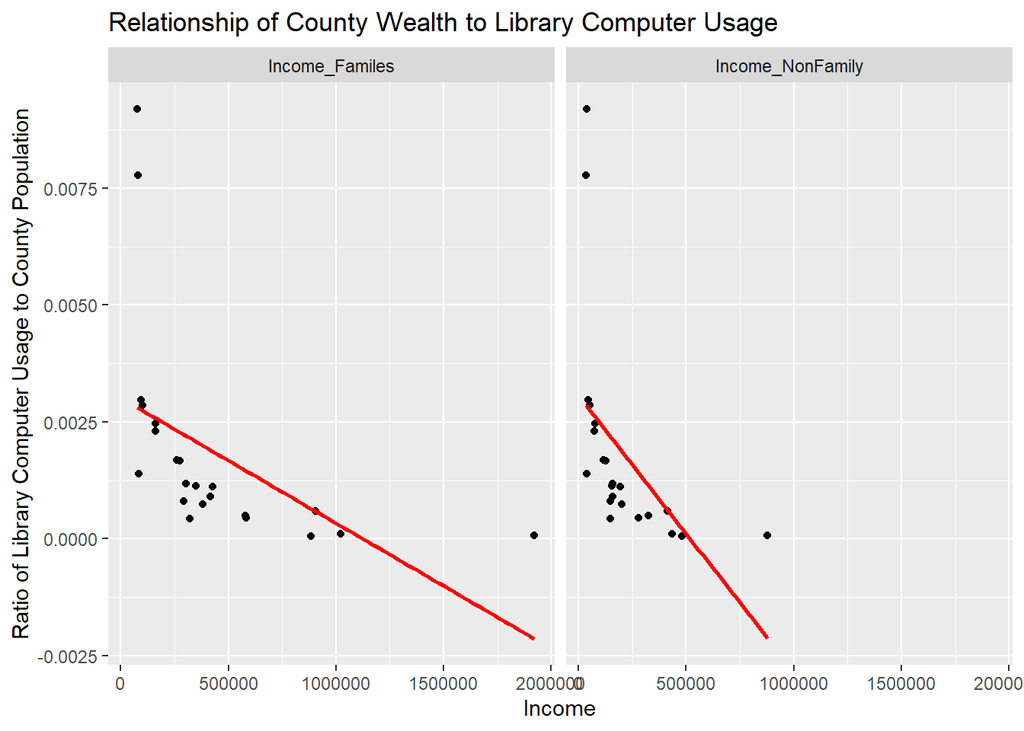

```r
computer_usage_graph <- computer_Usage_Data %>%
  left_join(library_income_costs, by="County") %>%
  select("Total_Population", "Uses_per_Computer", "Library_Visits", "Income_Familes", "Wireless_Internet_Uses", "Income_NonFamily", "County") %>%
  pivot_longer(cols = c("Income_Familes", "Income_NonFamily"), names_to = "Income_Type", values_to = "Income")

computer_usage_graph %>%
  ggplot(aes(x = Income, y = Uses_per_Computer/Total_Population)) +
  geom_point() +
  labs(y = "Ratio of Library Computer Usage to County Population", x = "Income", title = "Relationship of County Wealth to Library Computer Usage") +
  geom_smooth(method = lm, se=FALSE, color="red") +
  facet_wrap(~Income_Type)
```

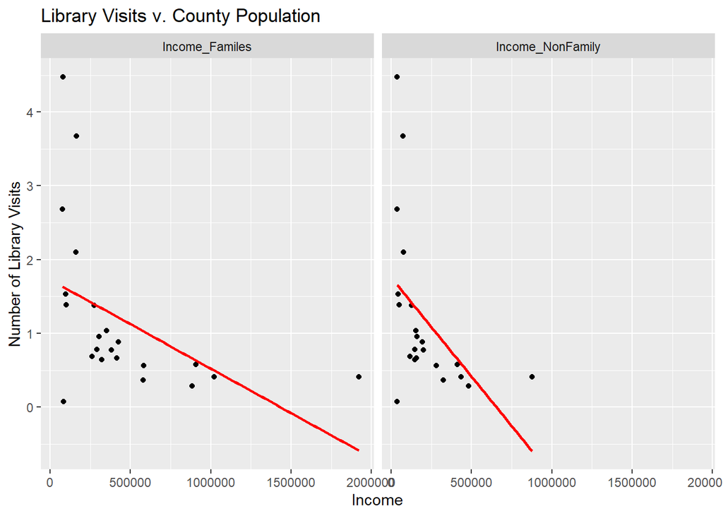

```r
computer_usage_graph %>%
  ggplot(aes(x = Income, y = Library_Visits/Total_Population)) +
  geom_point() +
  labs(x = "Income", y = "Number of Library Visits", title = "Library Visits v. County Population") +
  geom_smooth(method = lm, se=FALSE, color="red") +
  facet_wrap(~Income_Type)
```

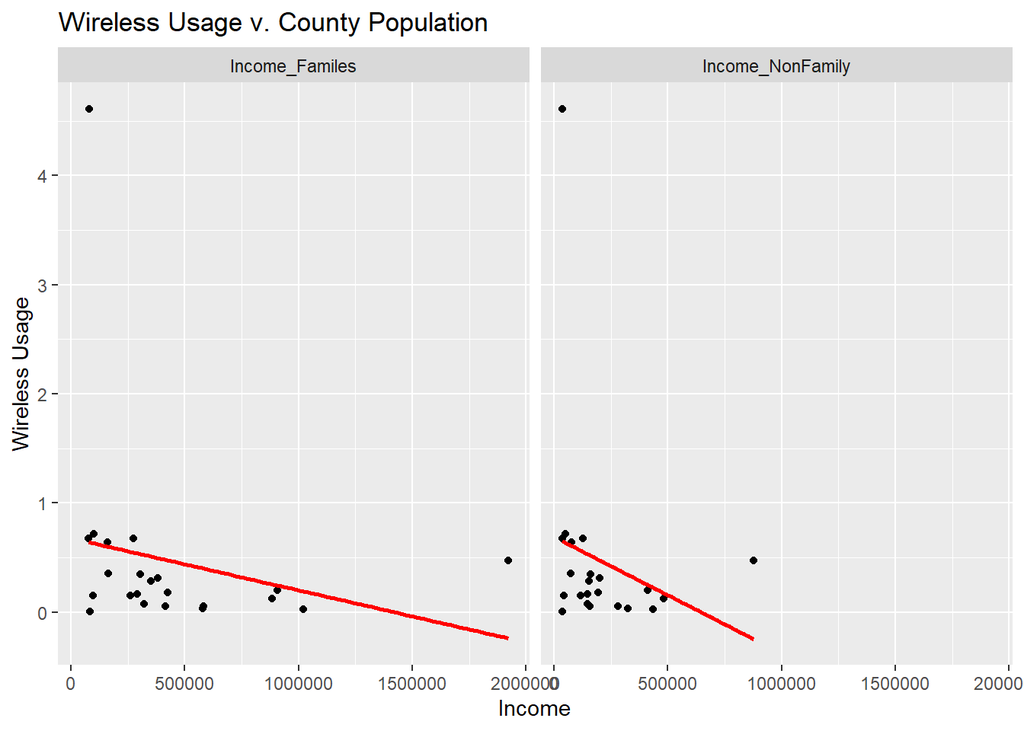

```r
computer_usage_graph %>%
  ggplot(aes(x = Income, y = Wireless_Internet_Uses/Total_Population)) +
  geom_point() +
  labs(x = "Income", y = "Wireless Usage", title = "Wireless Usage v. County Population") +
  geom_smooth(method = lm, se=FALSE, color="red") +
  facet_wrap(~Income_Type)
```

```r
# Some outlining data points

# Dane County Median Income is MUCH HIGHER than other places
computer_Usage_Data %>%
  select(matches("ncome")) %>%
  filter(Income_Familes > 1500000)
```

```
## # A tibble: 1 x 3
## # Groups:   County [1]
##   County Income_Familes Income_NonFamily
##   <chr>           <dbl>            <dbl>
## 1 Dane          1921572           875736
```

```r
computer_usage_graph %>%
  filter(Wireless_Internet_Uses/Total_Population > 1)
```

```
## # A tibble: 2 x 7
## # Groups:   County [1]
##   Total_Population Uses_per_Comput~ Library_Visits Wireless_Intern~ County
##              <dbl>            <dbl>          <dbl>            <dbl> <chr>
## 1            70772             550.         316801           326301 Porta~
## 2            70772             550.         316801           326301 Porta~
## # ... with 2 more variables: Income_Type <chr>, Income <dbl>
```

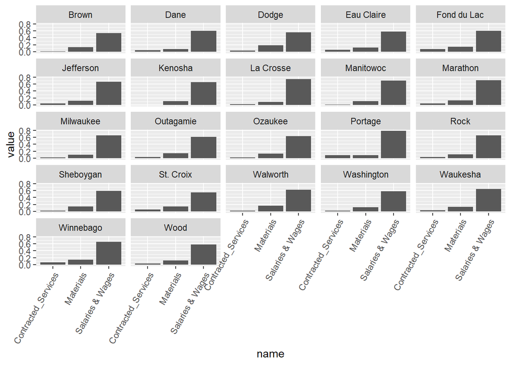

```r
library_income_costs %>%
  select(-c(Library_Income, Total_Operating_Expenditures, Resident_Support_per_Capita)) %>%
  mutate(Materials = sum(Print_Materials, Electronic_format, Audiovisual_Materials)) %>%
  select(`Salaries_&_Wages`, Materials, Contracted_Services, Other_Operating_Expenditures, County) %>%
  mutate(Total = sum(`Salaries_&_Wages`, Materials, Contracted_Services, Other_Operating_Expenditures)) %>%
  summarise(`Salaries & Wages` = `Salaries_&_Wages`/Total,
            Materials = Materials/Total,
            Contracted_Services = Contracted_Services/Total,
            Other = Other_Operating_Expenditures/Total) %>%

  pivot_longer(cols = matches("a")) %>%
  ggplot(aes(x = name, y = value)) +
  geom_bar(stat = "identity") +
  theme(axis.text.x = element_text(angle = 60, hjust = 1))+
  facet_wrap(~County)
```

# Old code